# Yogurt Study — Data Dictionary

Group A: Understanding the effect of yogurt consumption on the vaginal microbiome after antibiotic treatment

Author

Workshop Participant

## Overview

This dataset comes from a study looking at whether eating yogurt can help restore the vaginal microbiome after antibiotics. Participants were assigned to either a **yogurt** group (who ate yogurt daily) or an **unchanged diet** group (who didn’t change their eating habits).

Samples were collected at two time points:

- **Baseline** — before antibiotics
- **After antibiotic** — after a course of antibiotics

There are four CSV files. Below we load them and describe what each one contains.

```r
library(tidyverse)

# Helper to read a file and show a clean summary
read_and_describe <- function(path) {
  df <- read_csv(path, show_col_types = FALSE)
  cat("\nRows:", nrow(df), "  Columns:", ncol(df), "\n")
  glimpse(df)
  invisible(df)
}

data_dir <- "../group_a_yogurt"
```

## File 1: `00_sample_ids_yogurt.csv`

**What one row represents:** a single sample collected from one participant at one time point.

Each participant may appear twice (once at baseline, once after antibiotics) because they contributed one sample at each time point.

```r
sample_ids <- read_and_describe(file.path(data_dir, "00_sample_ids_yogurt.csv"))
```

```
Rows: 102   Columns: 4
Rows: 102
Columns: 4
$ pid        <chr> "pid_25", "pid_51", "pid_33", "pid_13", "pid_37", "pid_09",…
$ time_point <chr> "baseline", "baseline", "baseline", "baseline", "after_anti…
$ arm        <chr> "unchanged_diet", "yogurt", "yogurt", "yogurt", "unchanged_…
$ sample_id  <chr> "UNCH001", "YOG002", "YOG003", "YOG004", "UNCH005", "UNCH00…
```

| Column | Type | What it means |
| --- | --- | --- |
| `pid` | character | Participant ID (e.g. `pid_25`). Links to the metadata file. |
| `time_point` | character | When the sample was taken: `baseline` (before antibiotics) or `after_antibiotic` (after antibiotics). |
| `arm` | character | Which group the participant was in: `yogurt` (ate yogurt daily) or `unchanged_diet` (no change). |
| `sample_id` | character | Unique sample ID. Codes starting with `UNCH` are from the unchanged-diet arm; codes starting with `YOG` are from the yogurt arm. This is the key used to link to qPCR and Luminex results. |

## File 2: `01_participant_metadata_yogurt.csv`

**What one row represents:** one participant enrolled in the study.

There are 51 unique participants. Each participant appears exactly once here.

```r
metadata <- read_and_describe(file.path(data_dir, "01_participant_metadata_yogurt.csv"))
```

```
Rows: 51   Columns: 7
Rows: 51
Columns: 7
$ pid                 <chr> "pid_01", "pid_02", "pid_03", "pid_04", "pid_05", …
$ arm                 <chr> "unchanged_diet", "unchanged_diet", "unchanged_die…
$ days_since_last_sex <dbl> 2, 4, 3, 1, 5, 9, 3, 4, 10, 7, 9, 20, 1, 1, 11, 3,…
$ birth_control       <chr> "no hormonal birth control", "Depoprovera", "no ho…
$ age                 <dbl> 28, 34, 32, 30, 34, 27, 25, 26, 34, 32, 32, 32, 30…
$ education           <chr> "grade 10-12, not matriculated", "less than grade …
$ sex                 <chr> "female", "female", "female", "female", "female", …
```

| Column | Type | What it means |
| --- | --- | --- |
| `pid` | character | Participant ID — matches the same IDs in `sample_ids`. |
| `arm` | character | Group assignment: `yogurt` or `unchanged_diet`. |
| `days_since_last_sex` | double | Number of days since the participant last had sexual intercourse at the time of the baseline visit. |
| `birth_control` | character | Type of birth control used: `no hormonal birth control`, `Depoprovera` (an injectable hormonal contraceptive). |
| `age` | double | Participant’s age in years. |
| `education` | character | Highest education level completed: `less than grade 9`, `grade 10-12, not matriculated`, `grade 10-12, matriculated`, or `post-secondary`. |
| `sex` | character | All participants are recorded as `female`. |

## File 3: `02_qpcr_results_yogurt.csv`

**What one row represents:** the qPCR (quantitative PCR) measurements for one sample. qPCR is a lab technique that measures how much of a specific bacterium’s DNA is present.

```r
qpcr <- read_and_describe(file.path(data_dir, "02_qpcr_results_yogurt.csv"))
```

```
Rows: 102   Columns: 4
Rows: 102
Columns: 4
$ sample_id      <chr> "UNCH092", "UNCH042", "UNCH015", "UNCH035", "UNCH019", …
$ qpcr_bacteria  <dbl> 3093064.20, 8275.04, 7532202.40, 4794320.40, 5328343.60…
$ qpcr_crispatus <dbl> 0.000, 0.000, 0.000, 12.994, 0.000, 0.000, 0.000, 38.58…
$ qpcr_iners     <dbl> 26.840, 76.040, 554.964, 204308.968, 107806.148, 121045…
```

| Column | Type | What it means |
| --- | --- | --- |
| `sample_id` | character | Sample ID — links to `sample_ids`. |
| `qpcr_bacteria` | double | Total bacterial DNA measured, in **copies per mL** (or equivalent unit). A higher number means more bacteria overall. |
| `qpcr_crispatus` | double | DNA measure specifically for *Lactobacillus crispatus*, a “good” bacterium often linked to vaginal health. In **copies per mL**. A value of 0 means it was not detected. |
| `qpcr_iners` | double | DNA measure specifically for *Lactobacillus iners*, another common vaginal *Lactobacillus* species. In **copies per mL**. |

> **Note:** *L. crispatus* is generally considered beneficial for vaginal health, while *L. iners* is sometimes associated with a less stable microbiome. You may want to compare how these change between baseline and after antibiotics across the two arms.

## File 4: `03_luminex_results_yogurt.csv`

**What one row represents:** the concentration of **one cytokine** measured in **one sample**. This is “long” (tidy) format — each sample has 10 rows, one per cytokine measured.

Cytokines are small proteins released by immune cells that act as chemical messengers. They help us understand the immune / inflammatory state at the sampling site.

```r
luminex <- read_and_describe(file.path(data_dir, "03_luminex_results_yogurt.csv"))
```

```
Rows: 1020   Columns: 4
Rows: 1,020
Columns: 4
$ sample_id <chr> "UNCH092", "UNCH092", "UNCH092", "UNCH092", "UNCH092", "UNCH…
$ cytokine  <chr> "IL-1a", "IL-10", "IL-1b", "IL-8", "IL-6", "TNFa", "IP-10", …
$ conc      <dbl> 5.8500, 0.7670, 0.2505, 7.9200, 0.0935, 0.4710, 177.3800, 36…
$ limits    <chr> "within limits", "out of range", "out of range", "within lim…
```

```r
cat("Unique cytokines measured:",
    paste(unique(luminex$cytokine), collapse = ", "))
```

```
Unique cytokines measured: IL-1a, IL-10, IL-1b, IL-8, IL-6, TNFa, IP-10, MIG, IFN-Y, MIP-3a
```

[output not shown]

### What each cytokine generally tells you

| Cytokine | Role (simplified) |
| --- | --- |
| **IL-1a** | Pro-inflammatory — signals tissue damage or infection |
| **IL-1b** | Pro-inflammatory — one of the first signals in an immune response |
| **IL-6** | Pro- and anti-inflammatory — involved in fever and immune activation |
| **IL-8** | Chemokine — recruits immune cells to the site of infection |
| **IL-10** | Anti-inflammatory — helps calm down immune responses |
| **TNFa** | Pro-inflammatory — a major “alarm” cytokine |
| **IFN-Y** | Pro-inflammatory — important for fighting viral and bacterial infections |
| **IP-10** | Chemokine — attracts immune cells; often high during inflammation |
| **MIG** | Chemokine — similar to IP-10, attracts immune cells |
| **MIP-3a** | Chemokine — helps guide immune cells to tissues |

## How the files connect

Here’s a visual of how the files relate to each other — a simple relational “schema”:

```
  01_participant_metadata     00_sample_ids
  ┌──────────────────┐        ┌──────────────────┐
  │ pid (primary key)│◄───────│ pid (foreign key) │
  │                  │        │ sample_id (PK)   │
  └──────────────────┘        └───────┬──────────┘
                                      │
                         ┌────────────┼────────────┐
                         │            │            │
                         ▼            ▼            ▼
              ┌─────────────────┐ ┌─────────────────────┐
              │ 02_qpcr_results │ │ 03_luminex_results  │
              │ sample_id (FK)  │ │ sample_id (FK)      │
              └─────────────────┘ └─────────────────────┘
```

**To combine them in R**, you would join on `pid` (for metadata ↔︎ samples) or on `sample_id` (for samples ↔︎ qPCR / Luminex). Here’s an example:

```r
# Combine sample info with metadata
full_data <- sample_ids %>%
  left_join(metadata, by = "pid") %>%
  left_join(qpcr, by = "sample_id") %>%
  left_join(luminex, by = "sample_id")

head(full_data)
```

[output not shown]

## Quick exploration ideas

Here are a few small things you might try to get familiar with the data:

```r
# How many participants in each arm?
sample_ids |>
  distinct(pid, arm) |>
  count(arm)
```

```
# A tibble: 2 × 2
  arm                n
  <chr>          <int>
1 unchanged_diet    25
2 yogurt            26
```

```r
# Age range of participants
summary(metadata$age)
```

```
   Min. 1st Qu.  Median    Mean 3rd Qu.    Max.
  24.00   28.00   31.00   30.73   33.00   37.00
```

```r
# Which cytokines are most often out of range?
luminex |>
  count(cytokine, limits) |>
  filter(limits == "out of range") |>
  arrange(desc(n))
```

```
# A tibble: 9 × 3
  cytokine limits           n
  <chr>    <chr>        <int>
1 IL-10    out of range   102
2 IFN-Y    out of range   101
3 TNFa     out of range   100
4 IL-6     out of range    77
5 IL-1b    out of range    74
6 MIP-3a   out of range    24
7 MIG      out of range    13
8 IL-8     out of range     4
9 IP-10    out of range     3
```

```r
# Compare total bacteria between arms and time points
sample_ids %>%
  left_join(qpcr, by = "sample_id") %>%
  group_by(arm, time_point) %>%
  summarise(
    mean_bacteria = mean(qpcr_bacteria, na.rm = TRUE),
    sd_bacteria = sd(qpcr_bacteria, na.rm = TRUE),
    .groups = "drop"
  )
```

```
# A tibble: 4 × 4
  arm            time_point       mean_bacteria sd_bacteria
  <chr>          <chr>                    <dbl>       <dbl>
1 unchanged_diet after_antibiotic       926783.    1498748.
2 unchanged_diet baseline             16359934.   19998641.
3 yogurt         after_antibiotic       565014.    1364021.
4 yogurt         baseline             19498560.   28613780.
```

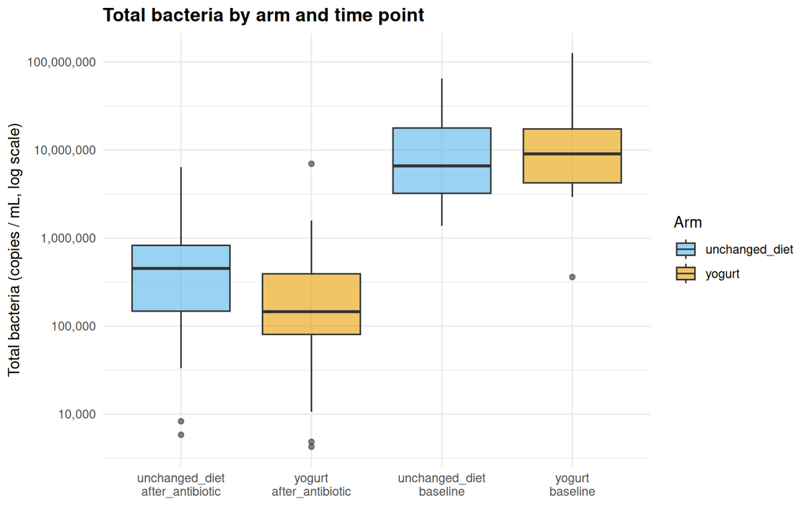

```r
# Boxplot: total bacteria by arm and time point
sample_ids %>%
  left_join(qpcr, by = "sample_id") %>%
  ggplot(aes(x = interaction(arm, time_point, sep = "\n"),
             y = qpcr_bacteria, fill = arm)) +
  geom_boxplot(alpha = 0.6) +
  scale_y_log10(labels = scales::label_comma()) +
  labs(
    x = NULL,
    y = "Total bacteria (copies / mL, log scale)",
    title = "Total bacteria by arm and time point",
    fill = "Arm"
  ) +
  theme_minimal() +
  theme(plot.title = element_text(face = "bold")) +
  scale_fill_manual(values = c("yogurt" = "#E69F00", "unchanged_diet" = "#56B4E9"))
```